# second hand bikes Market Insights & Price Intelligence using Web Scraping and EDA

### Which brand vehicle has the highest priced vehicle

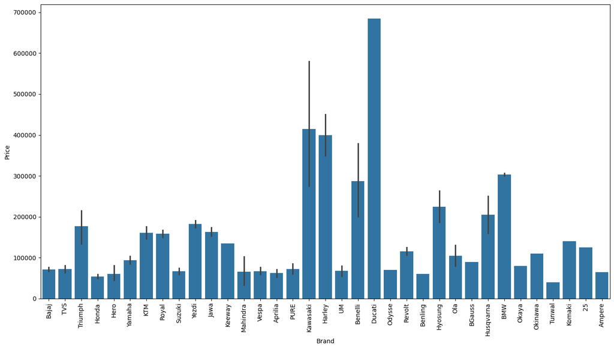

```python
plt.figure(figsize = (14,8))
sns.barplot(data = df,x = 'Brand',y = 'Price')
plt.xticks(rotation = 90)
plt.tight_layout()
plt.show()
```

```python
df['Price'].where(df['Price']>300000).mean()
```

```
np.float64(496666.6666666667)
```

- Ducati,Kawasaki,Harley,BMW,Benelli brand has the highest priced vehicle (Avg:Rs 496666)

## A Custom searching function to find a best bike according to the requirement

```python
def custom():
    global i,j,k,l,m
    i = input("Enter the brand you are searching for")
    i = i.capitalize()
    j = input("Enter your maximum budget ")
    k = input("Enter maximum Km's travelled bike you are looking for")
    l = int(input("Enter the oldest year you are looking for"))
    m = input("enter your location")

    try:
        print(df[(df['Brand']==i) & ( df['Price']<int(j)) & (df['Km']<int(k)) & (df['Year']>int(l))& (df['location'] == m ]))
    except(ValueError):
        pass

custom()
```

[output not shown]

### What is the availability of bikes based on location? How many bikes are available in Hyderabad?

```python
df['Location'].value_counts().head(15)
```

```
Location
Delhi        243
Mumbai       110
Bangalore    108
Pune          84
Hyderabad     76
Kolkata       63
Noida         44
Gurgaon       36
Chennai       36
Ghaziabad     32
Ahmedabad     32
Lucknow       20
Faridabad     18
Indore        17
Jaipur        14
Name: count, dtype: int64
```

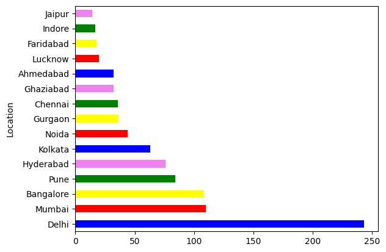

```python
df['Location'].value_counts().head(15).plot(kind = 'barh',color = ['blue','red','yellow','green','violet'])
```

## Which handed Vehicles are listed for Sale

```python
df['Hand'].value_counts()
```

```
Hand
First     1021
Second     167
Third       36
Name: count, dtype: int64
```

[figure not shown]

```python
df[''].value_counts().plot(kind = 'bar')
```

- There are 1021 sellers who bought their bike first hand.
- There are 167 sellers who bought their bike for second hand.
- There are 36 sellers who bought their bike for third hand.

## Analyze Which year's vehicles are listed more for resale

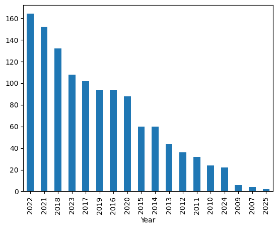

```python
df['Year'].value_counts().head(19).plot(kind = 'bar')
```

- There are more number bikes for sale which are brought in 2022(164).
- Followed by 2021(152),2018(132),2023(108),2017(102).
- Bikes which are bought recently are less likely to be resaled.
- 2024(22),2025(2 If you want ratest bikes .Sorry they are less in number

```python
df['Year'].value_counts()
```

```
Year
2022    164
2021    152
2018    132
2023    108
2017    102
2019     94
2016     94
2020     88
2015     60
2014     60
2013     44
2012     36
2011     32
2010     24
2024     22
2009      6
2007      4
2025      2
Name: count, dtype: int64
```

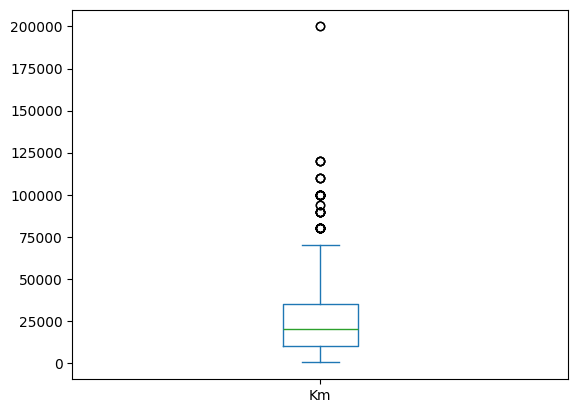

```python
df['Km'].plot(kind = 'box')
```

- The minimum distance travelled by a bike is 273km.
- The maximum distance travelled by a bike is 200000km.
- Most of the bikes have travelled less than 75000km.
- There are 54 bikes that have travelled more than 75000km

```python
df.describe()
```

[output not shown]

```python
(df['Km']>75000).value_counts()
```

```
Km
False    1170
True       54
Name: count, dtype: int64
```

# Bivariate

### How Year is effecting price of a bike

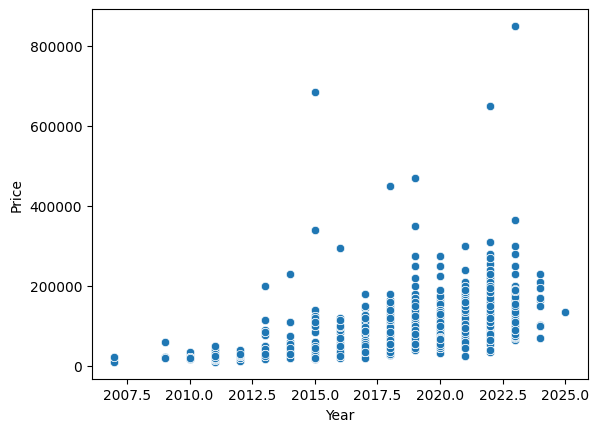

```python
sns.scatterplot(x = 'Year',y = 'Price',data= df)
```

- when we ignore outliers the graph indicates a positive curve which indicates
- The latest bikes are costly than the old bikes
- If you want to own a latest bike you have to pay more

```python
df['Year']
```

```
0       2018
1       2022
2       2018
3       2024
4       2019
        ...
1219    2022
1220    2021
1221    2019
1222    2016
1223    2022
Name: Year, Length: 1224, dtype: int64
```

## How the No.of Km's driven impact the bikes pricing?

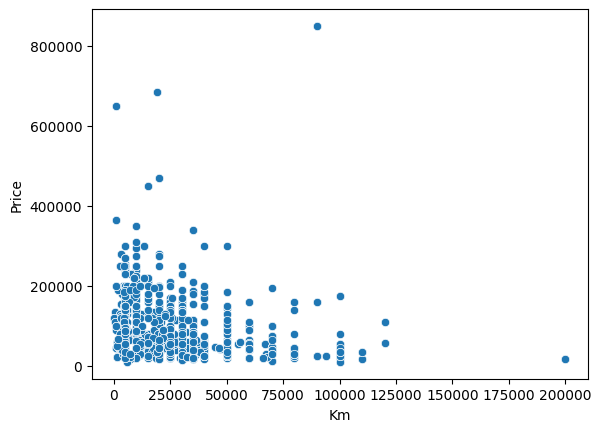

```python
sns.scatterplot(x = 'Km',y = 'Price',data= df,palette = True)
```

## In which Cities have greater availability of Resale bikes?

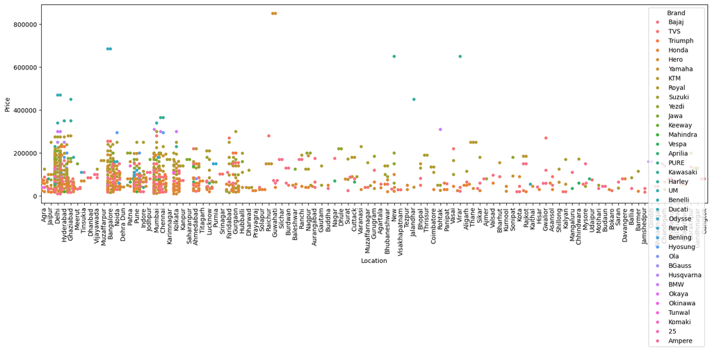

```python
plt.figure(figsize = (16,7))
sns.swarmplot(x = 'Location',y = 'Price',data = df,hue = 'Brand')
plt.xticks(rotation = 90)
plt.tight_layout()
plt.show()
```

- In Metropolitan and tier 2 cities(like Faridabad ,Ghaziabad) have more bikes for Resale than other cities.
- we have more options in metropolitan cities compared to other cities

## Analyze starting and highend price range of all the vehicles listed

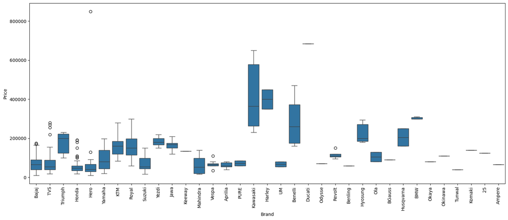

```python
plt.figure(figsize = (16,7))
sns.boxplot(x = 'Brand',y = 'Price',data = df)
plt.xticks(rotation = 90)
plt.tight_layout()
plt.show()
```

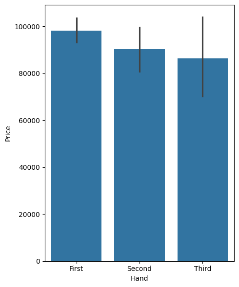

```python
plt.figure(figsize = (5,6))
sns.barplot(x = 'Hand',y = 'Price',data = df)
#plt.xticks(rotation = 90)
plt.tight_layout()
plt.show()
```

- Hand is affecting Price .
- First hand bikes when sold are costlier than second hand bikes and third hand bikes

# Multivariate

```python
df.corr(numeric_only=True,method = 'spearman')
```

|  | Price | Km | Year |
| --- | --- | --- | --- |
| Price | 1.000000 | -0.373473 | 0.665752 |
| Km | -0.373473 | 1.000000 | -0.425636 |
| Year | 0.665752 | -0.425636 | 1.000000 |

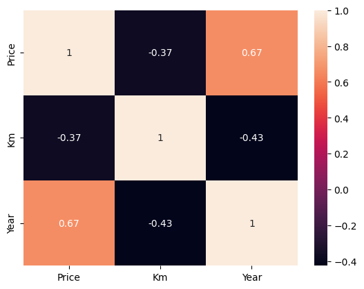

```python
sns.heatmap(df.corr(numeric_only = True,method = 'spearman'),annot=True)
```

- The corrrelation between the year(of the purchase) and the price of the bikes is Positive moderate kind of relation
- The corrrelation between the year(of the purchase) and the Km of the bike is negative moderate kind of relation.(as km increases ,Thebike becomes old.)
- The corrrelation between the Km and the price of the bikes is negative moderate kind of relation(As no . Km increases, Price decreases)
- The corrrelation between km and the year of the bikes is negative moderate kind of relation (The lesser the number of Km ,The latest the bike is).
- Therefore the year of the bike purchase has more effect on price of the bike than no. of Km

## Analyze what vehicle lasts long based on KM's travelled?

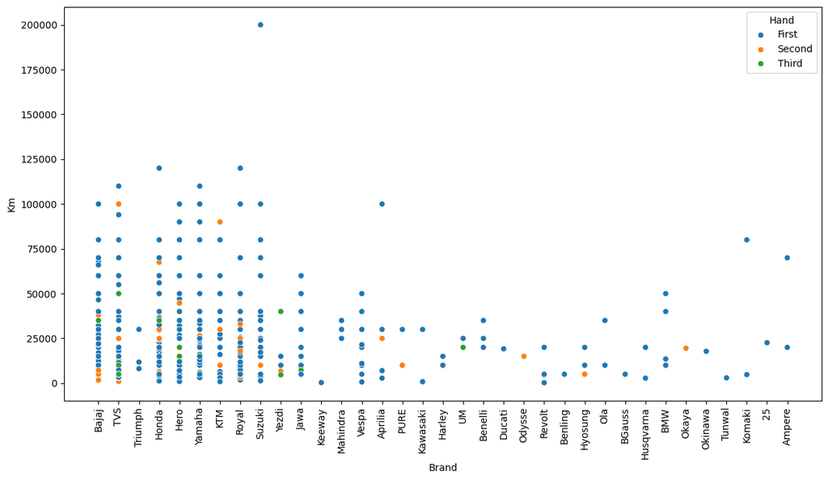

```python
plt.figure(figsize = (12,7))
sns.scatterplot(data = df,x = 'Brand',y = 'Km',hue = 'Hand')
plt.xticks(rotation = 90)
plt.tight_layout()
plt.show()
```

- A Suzuki vehicle has travelled around 2LAkh KM's. (penetrated brand : Bajaj, Service : Suzuki)
- Honda and Royal Enfield vehicle has travelled nearly 1,25,000.
- If we choose these vehicles to buy for second hand they might be worthy

## Can we Discard Second and third hand bikes from consideration

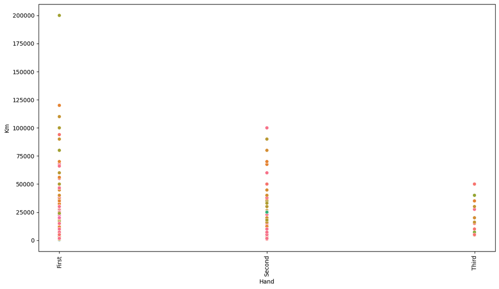

```python
plt.figure(figsize = (12,7))
sns.scatterplot(data = df,x = 'Hand',y = 'Km',hue = 'Brand',legend = False)
plt.xticks(rotation = 90)
plt.tight_layout()
plt.show()
```

- The Hand of the bike is not Affecting the Km driven of any brand
- Most of the First hand bikes are driven below 75000
- Most of the secound hand and Third hand bikes are driven below 50000 km
- Most of the bikes listed for resale are first hand from all brands
- If a third hand bike travelled less than 12000Km .Then the vehicle is as good as new.

## Identify Which bike does not lasts till third hand?

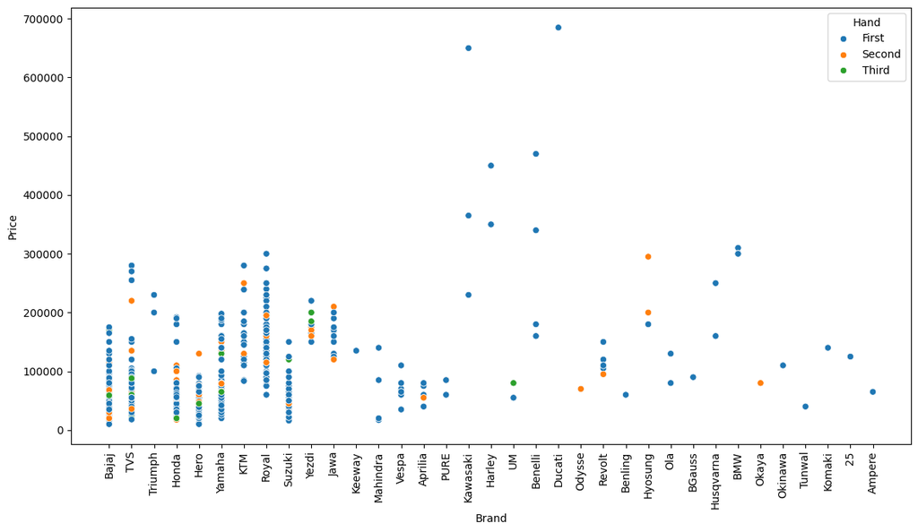

```python
plt.figure(figsize = (12,7))
sns.scatterplot(data = df,x = 'Brand',y = 'Price',hue = 'Hand')
plt.xticks(rotation = 90)
plt.tight_layout()
plt.show()
```

```python
df.drop(columns = 'Unnamed: 0',inplace = True)
```

```python
df= pd.read_csv("VisualKharido.csv")
```

```python
df
```

|  | Vehicle | Price | Km | Location | Hand | Year | Brand |
| --- | --- | --- | --- | --- | --- | --- | --- |
| 0 | Pulsar NS160 STD | 75000 | 20000 | Agra | First | 2018 | Bajaj |
| 1 | Sport Kick Start Alloy Wheel | 35000 | 10000 | Jaipur | First | 2022 | TVS |
| 2 | Apache RTR 200 4V Standard BS4 | 40000 | 70000 | Delhi | First | 2018 | TVS |
| 3 | Speed 400 | 230000 | 8100 | Hyderabad | First | 2024 | Triumph |
| 4 | Livo BS4 | 45000 | 20000 | Ghaziabad | Second | 2019 | Honda |
| ... | ... | ... | ... | ... | ... | ... | ... |
| 1219 | Scrambler Single Tone | 200000 | 40000 | Nagpur | Third | 2022 | Yezdi |
| 1220 | Passion Pro XTec Drum | 45000 | 20000 | Indore | Third | 2021 | Hero |
| 1221 | SR 125 2020 Analog | 55000 | 25000 | Delhi | Second | 2019 | Aprilia |
| 1222 | Enfield Himalayan Snow White | 115000 | 33000 | Aligarh | Second | 2016 | Royal |
| 1223 | Enfield Meteor 350 Stellar Custom | 195000 | 18000 | Kolkata | Second | 2022 | Royal |

1224 rows × 7 columns

```python
df[df['Year'] > 2020]['Brand']['vehicle']
```

```python
df
```

|  | Vehicle | Price | Km | Location | Hand | Year | Brand |
| --- | --- | --- | --- | --- | --- | --- | --- |
| 0 | Pulsar NS160 STD | 75000 | 20000 | Agra | First | 2018 | Bajaj |
| 1 | Sport Kick Start Alloy Wheel | 35000 | 10000 | Jaipur | First | 2022 | TVS |
| 2 | Apache RTR 200 4V Standard BS4 | 40000 | 70000 | Delhi | First | 2018 | TVS |
| 3 | Speed 400 | 230000 | 8100 | Hyderabad | First | 2024 | Triumph |
| 4 | Livo BS4 | 45000 | 20000 | Ghaziabad | Second | 2019 | Honda |
| ... | ... | ... | ... | ... | ... | ... | ... |
| 1219 | Scrambler Single Tone | 200000 | 40000 | Nagpur | Third | 2022 | Yezdi |
| 1220 | Passion Pro XTec Drum | 45000 | 20000 | Indore | Third | 2021 | Hero |
| 1221 | SR 125 2020 Analog | 55000 | 25000 | Delhi | Second | 2019 | Aprilia |
| 1222 | Enfield Himalayan Snow White | 115000 | 33000 | Aligarh | Second | 2016 | Royal |
| 1223 | Enfield Meteor 350 Stellar Custom | 195000 | 18000 | Kolkata | Second | 2022 | Royal |

1224 rows × 7 columns

## When the budget is between 20 thousand to 50 thousand what are the brands available in this budget?

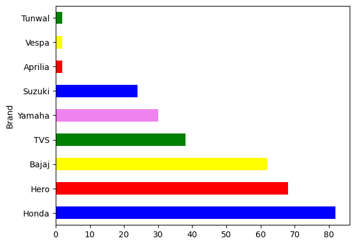

```python
df[(df['Price']>20000)&(df['Price']<(50000))]['Brand'].value_counts().plot(kind = 'barh',color = ['blue','red','yellow','green','violet'])
```

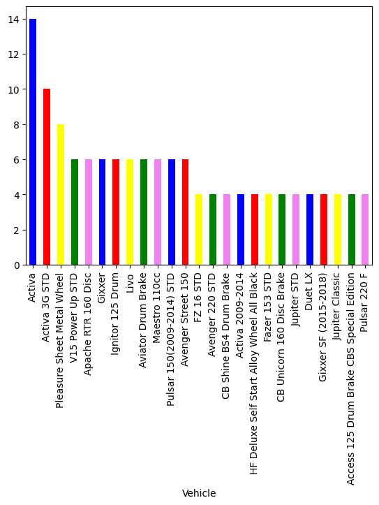

```python
df[(df['Price']>20000)&(df['Price']<(50000))]['Vehicle'].value_counts().head(25).plot(kind = 'bar',color = ['blue','red','yellow','green','violet'])
```

## Best Deal

```python
df.loc[df['Brand']== 'Kawasaki']
```

|  | Vehicle | Price | Km | Location | Hand | Year | Brand |
| --- | --- | --- | --- | --- | --- | --- | --- |
| 197 | Ninja 300 | 365000 | 1125 | Chennai | First | 2023 | Kawasaki |
| 209 | Ninja 300 | 365000 | 1125 | Chennai | First | 2023 | Kawasaki |
| 584 | Ninja 650 | 230000 | 30000 | Delhi | First | 2014 | Kawasaki |
| 596 | Ninja 650 | 230000 | 30000 | Kolkata | First | 2014 | Kawasaki |
| 770 | Z650RS | 650000 | 800 | New | First | 2022 | Kawasaki |
| 782 | Z650RS | 650000 | 800 | Virar | First | 2022 | Kawasaki |